# S2b: Pollino Case-study - Building database augmentation

This notebook describes the augmentation of the building database and imputation of missing information. Specifically, the data obtained via the damage database and pre-processed in notebook S2a does not cover the entire building stock present in the region of interest.

The data augmentation includes four steps:

1. Calculation of the number of missing buildings in each municipality based on 2001 ISTAT census data.
2. Assign unique geo-coordinates to each added building based on the European Settlement Map.
3. Fill missing attributes (for example the construction period) based on 2001 ISTAT census data.
4. Attribute a EuroCode8 soil class to all buildings based on Forte et al. (2019)

This notebook includes all steps and assumptions, such that interested persons can reproduce the augmentation by: (1) following notebook S2a and (2) downloading the raw census data, European Settlement Map and soil class map. As of January 2021, the access to the three data sources is public. The full references of the underlying data sources are stated in the main paper.

```python
import geopandas
import numpy as np
import pandas as pd
import matplotlib.pyplot as plt
import os
```

## Pre-processing of census data

From the ISTAT2001 census data, following information for each municipality (comune) is used:

- E3: Total number of residential buildings
- E6: Number of masonry buildings
- E7: Number of reinforced concrete buildings
- E9: Number of buildings built before 1919
- E10: Number of buildings built between 1919 and 1945
- E11: Number of buildings built between 1946 and 1961
- E12: Number of buildings built between 1962 and 1971
- E13: Number of buildings built between 1972 and 1981
- E14: Number of buildings built between 1982 and 1991
- E15: Number of buildings built after 1992
- E16: Number of buildings with one story
- E17: Number of buildings with two stories
- E18: Number of buildings with three stories
- E19: Number of buildings with four and more stories

The variable 'PRO_COM' is used to identify the different municipalities.

```python
# We need the files for regions 17 and 18.
pathFile = os.path.normpath(os.path.normpath(os.getcwd() + os.sep + os.pardir ) + os.sep + os.path.join("ISTAT2001",
                                   "dati-cpa_2001",
                                   "R17_DatiCPA_2001.xls"))
dfc = pd.read_excel(pathFile)
dfc = dfc[['PRO_COM','E3','E6','E7','E9','E10','E11','E12','E13','E14','E15','E16','E17','E18','E19']]
pathFile = os.path.normpath(os.path.normpath(os.getcwd() + os.sep + os.pardir ) + os.sep + os.path.join("ISTAT2001",
                                   "dati-cpa_2001",
                                   "R18_DatiCPA_2001.xls"))
dfc2 = pd.read_excel(pathFile)
dfc2 = dfc2[['PRO_COM','E3','E6','E7','E9','E10','E11','E12','E13','E14','E15','E16','E17','E18','E19']]

# Combine both regions and sum the buildings for each 'PRO_COM':
dfc = dfc.append(dfc2,ignore_index=True)
dfsum = dfc.groupby('PRO_COM').sum().reset_index()
```

Load the administrative boundaries of every municipality in Italy. Those are the boundaries used within ISTAT2001. Census data is then merged with the administrative boundaries and transformed to the reference coordinate system used in the present study.

```python
ItalyLimitsPath = os.path.normpath(os.path.normpath(os.getcwd() + os.sep + os.pardir ) + os.sep + os.path.join("ISTAT2001",
                                   "Limiti2001_g","Com2001_g",
                                   "Com2001_g_WGS84.shp"))
gdf_ItalyLimits = geopandas.read_file(ItalyLimitsPath)
gdf_Mun = gdf_ItalyLimits.merge(dfsum,on='PRO_COM')
# Transform to the reference coordinate system used in this study (EPSG=3035)
gdf_Mun = gdf_Mun.to_crs(epsg=3035)
```

Load the observed damage data and the event characteristics.

```python
# df = pd.read_csv('Data/buildingdamage_dec.csv',delimiter=';')
df = pd.read_csv('Data/InspectionResults.csv')
# Create a GeoDataFrame and transform the coordinate system
gdf_DS = geopandas.GeoDataFrame(
    df, geometry=geopandas.points_from_xy(df['coordinate_lon'], df['coordinate_lat']))
gdf_DS = gdf_DS.set_crs(epsg=4326)
ggdf_DS = gdf_DS.to_crs(epsg=3035)
```

Attribute the municipality index ('PRO_COM') to each building with inspection data via a spatial join and calculate the number of missing buildings in each municipality.

```python
from geopandas.tools import sjoin
join_gdf_DS = sjoin(gdf_Mun, ggdf_DS, how="right", op="contains")
grouped = join_gdf_DS.groupby('PRO_COM')
data = d = {'PRO_COM': grouped.size().reset_index().values[:,0], 'nI': grouped.size().reset_index().values[:,1]}
join_gdf_Mun = gdf_Mun.merge(pd.DataFrame(data=data),on='PRO_COM',how='left')
join_gdf_Mun = join_gdf_Mun.fillna(value={'nI': 0})
join_gdf_Mun['RemBuil'] = join_gdf_Mun.E3 - join_gdf_Mun.nI
```

Build a new dataframe for the buildings with inspection data that is limited to the relevant information.

- indexB: This is the index that allows to link an entry to the entry in the original damage database containing all detailed information.
- x: x-coordinate in the case-study coordinate system.
- y: y-coordinate in the case-study coordinate system.
- PRO_COM: The id of the municipality the building is located.
- ConstrPeriod: The construction period.
- Nstories: The number of stories.
- VulClass: The vulnerability class (building type).
- DS: The attributed damage state of each building.

```python
dfObs_Mun = join_gdf_DS[['indexB','PRO_COM','Nstories','ConstrPeriod','DS','VulClass']].copy()
dfObs_Mun['x'] = join_gdf_DS.geometry.values.x
dfObs_Mun['y'] = join_gdf_DS.geometry.values.y
```

We filter the administrative boundaries and census data, as well as the buildings with inspection data, to our region of interest.

```python
MunList = [76042, 76092, 76044, 76023, 76022, 76070, 76097,
           76040, 76068, 76054, 76039, 78149, 78063, 78064]
join_gdf_Mun = join_gdf_Mun[np.isin(join_gdf_Mun.PRO_COM, MunList)].copy()
dfObs_Mun = dfObs_Mun[np.isin(dfObs_Mun.PRO_COM, MunList)].copy()
```

The geo-coordinates of buildings with inspection data (as described in Appendix A2.1) have a lot of duplicated values. Whereas one result corresponds to one building, often results for the same municipality are attributed with the same geo-coordinates. We store these cases in a separate dataframe and we will assign unique geo-coordinates based on the European Settlement Map in the next step.

```python
dfdup = dfObs_Mun[dfObs_Mun.duplicated(subset=['x','y'], keep=False)].copy()
```

## Attribute geo-coordinates

The European Settlement map shows for 10x10m pixels, whether it is built-up by residential buildings or not. We use this map to sample geo-coordinates for augmented buildings and for buildings with inspection data but duplicated geo-coordinates.

```python
# Specify the paths to the original .tif files
tiff_path_N19E47 = os.path.join("Data",
                                   "EuropeanSettlement2019",
                                   "ESM_BUILT_VHR2015CLASS_R2019_3035_N19E47_010m_v010.tif")
tiff_path_N19E48 = os.path.join("Data",
                                   "EuropeanSettlement2019",
                                   "ESM_BUILT_VHR2015CLASS_R2019_3035_N19E48_010m_v010.tif")
tiff_path_combined = os.path.join("Data",
                                   "EuropeanSettlement2019",
                                   "Combined.tif")

# Open the files using rasterio
import rasterio
from rasterio.merge import merge
src1 = rasterio.open(tiff_path_N19E47)
src2 = rasterio.open(tiff_path_N19E48)

out_merged, out_transform = merge([src1, src2])
out_meta = src1.meta.copy()

out_meta.update({'width': out_merged.shape[2],
                 'height': out_merged.shape[1],
                 'transform': out_transform})

with rasterio.open(tiff_path_combined, "w", **out_meta) as dest1:
        dest1.write(out_merged)
```

```python
from rasterio.mask import mask
import warnings
warnings.filterwarnings('ignore')
Nmun = len(join_gdf_Mun)
Mun_list = join_gdf_Mun.PRO_COM.values
for MunI in np.arange(0,Nmun):
    geoms = join_gdf_Mun.geometry.values # list of shapely geometries
    # transform to GeoJSON format
    from shapely.geometry import mapping
    geoms = [mapping(geoms[MunI])]
    # extract the raster values within the polygon
    with rasterio.open(tiff_path_combined) as src:
         out_image, out_transform = mask(src, geoms, crop=True)

    # extract the values of the masked array
    data = out_image[0,:,:]
    # extract the row, columns of the valid values
    row, col = np.where(data == 255) # A value of 255 indicates "residential built-up"
    val = np.extract(data == 255, data)

    from rasterio import Affine # or from affine import Affine
    T1 = out_transform * Affine.translation(0.5, 0.5) # reference the pixel centre
    rc2xy = lambda r, c: (c, r) * T1
    # coordinate transformation
    d = geopandas.GeoDataFrame({'col':col,'row':row})
    # coordinate transformation
    d['x'] = d.apply(lambda row: rc2xy(row.row,row.col)[0], axis=1)
    d['y'] = d.apply(lambda row: rc2xy(row.row,row.col)[1], axis=1)

    # geometry
    from shapely.geometry import Point
    d['geometry'] =d.apply(lambda row: Point(row['x'], row['y']), axis=1)

    mun = Mun_list[MunI]
    # Move locations of duplicates in buildings with inspection data
    # to the closest "free" built-up pixel:
    if np.sum(dfdup.PRO_COM==mun) > 0:
        grouped = dfdup[dfdup.PRO_COM==mun].groupby(['x','y'])
        counter = 0
        for name, group in grouped:
            nB = len(group) - 1
            xt = np.unique(group.x)
            yt = np.unique(group.y)
            dist = np.sqrt((xt-d.x)**2 + (yt-d.y)**2)
            Samples = d.loc[np.argsort(dist).index][:nB]
            idx = group.index[1:]
            dfObs_Mun.loc[idx,'x'] = Samples.x.values
            dfObs_Mun.loc[idx,'y'] = Samples.y.values
            d = d.drop(Samples.index)

    # Generate geo-coordinates of uninspected buildings
    nB = join_gdf_Mun.RemBuil.values[MunI].astype('int32')
    if len(d) < nB: nB = len(d)

    # Sample "free" built-up pixels for each building
    Samples = d.sample(nB, random_state=1)

    Samples['PRO_COM'] = (Mun_list[MunI] * np.ones(nB)).astype('int32')
    data = {'PRO_COM': Samples.PRO_COM.values,
            'x': Samples.x.values,
            'y': Samples.y.values
            }

    if MunI == 0:
        dfremB = pd.DataFrame(data)
    else:
        dftemp = pd.DataFrame(data)
        dfremB = dfremB.append(dftemp,ignore_index=True)
```

The map shows the 14 subregions (municipalities) considered in the present study. The blue points relate to the augmented (or added) buildings and the orange points relate to buildings with inspection data (as described in Appendix B1).

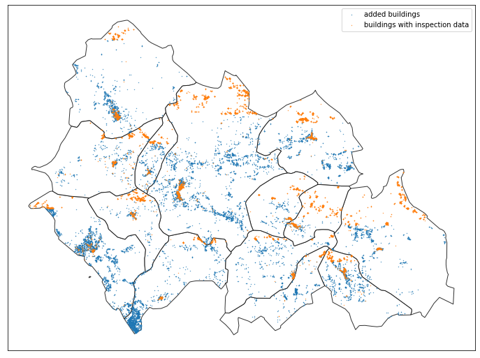

## Attribute remaining missing building information

Then attribute further missing information to the added buildings: The construction period, the height class and the vulnerability class. As described in the paper, all buildings without inspection data are assumed to be undamaged. The new dataframe contains all buildings.

```python
dfremB['ConstrPeriod'] = np.nan
dfremB['Nstories'] = np.nan
dfremB['VulClass'] = np.nan
dfremB['DS'] = 0
dfTot = dfObs_Mun.append(dfremB, ignore_index=True)
```

First, attribute the construction period, the height class and the building material (RC or Masonry). This is done by comparing the total number of buildings in a given construction period with the number of inspected buildings in that construction period. This gives us the proportions of the remaining buildings, based on which we sample a construction period for each building.

```python
from utilsSim import AttributionMatrix
grouped = dfTot.groupby('PRO_COM')
CP_list = ['<1919', '1919-1945', '1946-1961', '1962-1971', '1972-1981', '1982-1991', '>1991']
Vul_class_list_M = ['A','B','C1']
Vul_class_list_RC = ['C2','D']
Mat_list = ['M','RC']
for name, group in grouped:

    # Number of stories
    StoryCount_Census = join_gdf_Mun[join_gdf_Mun.PRO_COM==name][['E16','E17','E18','E19']].values[0,:]
    StoryCount_Observed, _ = np.histogram(group.Nstories.values.astype('int'),np.arange(1,6))
    if (np.sum(StoryCount_Census) - np.sum(StoryCount_Observed)) > 0:
        pSC_RemB = (StoryCount_Census - StoryCount_Observed) / (np.sum(StoryCount_Census) - np.sum(StoryCount_Observed))
        pSC_RemB[ pSC_RemB<0 ] = 0
        pSC_RemB = np.append(pSC_RemB,0)
        pSC_RemB[-2] = 0.7 * pSC_RemB[-2]
        pSC_RemB[-1] = 0.3 * pSC_RemB[-2]
        pSC_RemB = pSC_RemB / np.sum(pSC_RemB)
        Nb = np.sum(group.Nstories.isna())
        rng = np.random.default_rng(1)
        SCsamples = rng.choice(np.arange(1,6), Nb, replace=True, p=pSC_RemB)
        dfTot.loc[group[group.Nstories.isna()].index, 'Nstories'] = SCsamples

    # Construction period
    ConPCount_Census = join_gdf_Mun[join_gdf_Mun.PRO_COM==name][['E9','E10','E11','E12','E13','E14','E15']].values[0,:]
    ConPCount_Observed = np.zeros(7)
    for cp in np.arange(7):
        ConPCount_Observed[cp] = np.sum(group.ConstrPeriod==CP_list[cp])
    if (np.sum(ConPCount_Census) - np.sum(ConPCount_Observed)) > 0:
        pCP_RemB = (ConPCount_Census - ConPCount_Observed) / (np.sum(ConPCount_Census) - np.sum(ConPCount_Observed))
        pCP_RemB[ pCP_RemB<0 ] = 0
        pCP_RemB = pCP_RemB / np.sum(pCP_RemB)
        Nb = np.sum(group.ConstrPeriod.isna())
        rng = np.random.default_rng(1)
        CPsamples = rng.choice(np.arange(7), Nb, replace=True, p=pCP_RemB)
        dfTot.loc[group[group.ConstrPeriod.isna()].index, 'ConstrPeriod'] = np.stack(CP_list)[CPsamples.astype('int')]

    # Main construction material (RC or Masonry)
    # first establish the proportion of masonry and rc buildings
    MatCount_Census = join_gdf_Mun[join_gdf_Mun.PRO_COM==name][['E6','E7']].values[0,:]
    MatCensusProp = MatCount_Census/np.sum(MatCount_Census)
    # Then extrapolate to the total counts
    MatCount_Census = np.round(MatCensusProp*len(group)).astype('int32')
    # Attribute material to buildings with inspection data based on the vulnerability class
    dfTot.loc[group[np.isin(group.VulClass,Vul_class_list_M)].index,'Mat'] = 'M'
    dfTot.loc[group[np.isin(group.VulClass,Vul_class_list_RC)].index,'Mat'] = 'RC'
    # Count buildings with inspection data
    MatCount_Observed = np.array([np.sum(np.isin(group.VulClass,Vul_class_list_M)),
                                 np.sum(np.isin(group.VulClass,Vul_class_list_RC))])
    if (np.sum(MatCount_Census) - np.sum(MatCount_Observed)) > 0:
        pMat_RemB = (MatCount_Census - MatCount_Observed) / (np.sum(MatCount_Census) - np.sum(MatCount_Observed))
        pMat_RemB[pMat_RemB < 0] = 0
        pMat_RemB = pMat_RemB / np.sum(pMat_RemB)
        Nb = np.sum(group.VulClass.isna())
        rng = np.random.default_rng(1)
        Matsamples = rng.choice(np.arange(2), Nb, replace=True, p=pMat_RemB)
        dfTot.loc[group[group.VulClass.isna()].index, 'Mat'] = np.stack(Mat_list)[Matsamples.astype('int')]

# Transform to height classes: (Low-, Mid- and High-rise)
dfTot.loc[dfTot[(dfTot.Nstories <= 2)].index, 'HeightClass'] = 'LR'
dfTot.loc[dfTot[(dfTot.Nstories > 2) & (dfTot.Nstories <= 4)].index, 'HeightClass'] = 'MR'
dfTot.loc[dfTot[(dfTot.Nstories > 4)].index, 'HeightClass'] = 'HR'
dfTot = dfTot.drop(columns="Nstories")
```

Now simulate the building class for those buildings where this information is missing (See the definition of building classes in Appendix B1).

- For Masonry buildings, use the conditional probability table as stated in Table 7 in Rosti et al (2021).
- For Reinforced concrete buildings only separate based on the construction period.

Rosti A., Rota M. and Penna A. (2021): Empirical fragility curves for Italian URM buildings; Bulletin of Earthquake Engineering 19:3057–3076; 10.1007/s10518-020-00845-9

```python
CondProbMasonry = np.zeros((3, 6, 2))
CondProbMasonry[0, :, 0] = [0.86, 0.45, 0.09, 0.05, 0.00, 0.00]
CondProbMasonry[1, :, 0] = [0.00, 0.44, 0.59, 0.04, 0.00, 0.00]
CondProbMasonry[2, :, 0] = [0.14, 0.11, 0.32, 0.91, 1.00, 1.00]
CondProbMasonry[0, :, 1] = [0.97, 0.22, 0.00, 0.00, 0.00, 0.00]
CondProbMasonry[1, :, 1] = [0.00, 0.78, 0.75, 0.18, 0.00, 0.00]
CondProbMasonry[2, :, 1] = [0.03, 0.00, 0.25, 0.82, 1.00, 1.00]
```

```python
rng = np.random.default_rng(1)
for k, cp in enumerate(CP_list):
    if k>5: k = 5
    idx = dfTot[(dfTot.ConstrPeriod==cp) & (dfTot.VulClass.isna()) &
                (dfTot.Mat=='M') & (dfTot.HeightClass=='LR')].index
    nB = len(idx)
    if nB > 0:
        pVC = CondProbMasonry[:,k,0]
        VCsamples = rng.choice(np.arange(3), nB, replace=True, p=pVC)
        dfTot.loc[idx, 'VulClass'] = np.stack(Vul_class_list_M)[VCsamples.astype('int')]
    idx = dfTot[(dfTot.ConstrPeriod==cp) & (dfTot.VulClass.isna()) &
                (dfTot.Mat=='M') & (dfTot.HeightClass!='LR')].index
    nB = len(idx)
    if nB > 0:
        pVC = CondProbMasonry[:,k,1]
        VCsamples = rng.choice(np.arange(3), nB, replace=True, p=pVC)
        dfTot.loc[idx, 'VulClass'] = np.stack(Vul_class_list_M)[VCsamples.astype('int')]
    idx = dfTot[(dfTot.ConstrPeriod==cp) & (dfTot.VulClass.isna()) &
            (dfTot.Mat=='RC')].index
    nB = len(idx)
    if nB > 0:
        if k <= 2: dfTot.loc[idx, 'VulClass'] = 'C2'
        else: dfTot.loc[idx, 'VulClass'] = 'D'

dfTot = dfTot.drop(columns='Mat')
```

## Attribute Soil class

Forte et al. (2019) provide soil conditions, in terms of EuroCode8 soil classes, for Italy as maps together with a supporting software for data export. A map for the region of this case-study was exported and geo-referenced using standard GIS tools. The map indicates three different soil classes (A,B and C) with different colors. For each building, the soil class of the closest pixel in the map is attributed based on its color.

Forte G., Chioccarelli E., De Falcoa M., Cito P., Santoa A. and Iervolino I. (2019): Seismic soil classification of Italy based on surface geology and shear-wave velocity measurements; Soil Dynamics and Earthquake Engineering; 122: 79-93

The first step pertains to building a dataframe with all pixel centers and the corresponding soil class.

```python
# Open the geo-referenced soil class map
tiff_path_SC = os.path.join("Data",
                                   "SiteClassification",
                                   "SiteClasses.tif")
import rasterio
from rasterio.merge import merge
src = rasterio.open(tiff_path_SC)

band1 = src.read(1)
band2 = src.read(2)
band3 = src.read(3)
# Soil Class A:
mask = (band1 == 0) & (band2 == 153) & (band3 == 0)
rowA, colA = np.where(mask)
# Soil Class B:
mask = (band1 == 153) & (band2 == 255) & (band3 == 51)
rowB, colB = np.where(mask)
# Soil Class C:
mask = (band1 == 255) & (band2 == 153) & (band3 == 51)
rowC, colC = np.where(mask)

out_transform = src.transform
from rasterio import Affine # or from affine import Affine
T1 = out_transform * Affine.translation(0.5, 0.5) # reference the pixel centre
rc2xy = lambda r, c: (c, r) * T1
# coordinate transformation
d = geopandas.GeoDataFrame({'col':colA,'row':rowA,'val': 'A'})
dataB = geopandas.GeoDataFrame({'col': colB, 'row': rowB, 'val': 'B'})
dataC = geopandas.GeoDataFrame({'col': colC, 'row': rowC, 'val': 'C'})
d = d.append(dataB,ignore_index=True)
d = d.append(dataC,ignore_index=True)
# coordinate transformation
d['x'] = d.apply(lambda row: rc2xy(row.row,row.col)[0], axis=1)
d['y'] = d.apply(lambda row: rc2xy(row.row,row.col)[1], axis=1)

# geometry
from shapely.geometry import Point
d['geometry'] =d.apply(lambda row: Point(row['x'], row['y']), axis=1)
```

In a second step, the closest pixel to every building is calculated and the corresponding soil class attributed to the building.

```python
# Create a geodataframe and transform it to lon/lat coordinates
gdfTot = geopandas.GeoDataFrame(
    dfTot, geometry=geopandas.points_from_xy(dfTot['x'], dfTot['y']))
gdfTot = gdfTot.set_crs(epsg=3035)
gdfTot = gdfTot.to_crs(epsg=4326)

# This short function provides soil class of the closest pixel center for each building
from scipy.spatial import cKDTree
def ckdnearest(gdA, gdB):

    nA = np.array(list(gdA.geometry.apply(lambda x: (x.x, x.y))))
    nB = np.array(list(gdB.geometry.apply(lambda x: (x.x, x.y))))
    btree = cKDTree(nB)
    dist, idx = btree.query(nA, k=1)
    gdB_nearest = gdB.iloc[idx].drop(columns="geometry").reset_index(drop=True)
    gdf = pd.concat(
        [
            gdA.reset_index(drop=True),
            gdB_nearest['val']
        ],
        axis=1)

    return gdf

# Apply the function
gdfTotSC = ckdnearest(gdfTot, d)
```

The resulting dataframe consists of the building-specific information considered for the Pollino case-study. As discussed in the paper, the attribute 'VulClass' (as well as 'DS' for obvious reasons) become only available once a building is inspected. Notebook S3 explains the prior risk model, used for this case-study and how it processes the available attributes.

```python
# Delete the geometry column and rename
dfTotSC = gdfTotSC.drop(columns="geometry").rename(columns={'val': 'SoilClassEC'})
# Save the dataframe as a csv file
dfTotSC.to_csv('Data\BuildingsInfo.csv')
dfTotSC
```

|  | indexB | PRO_COM | ConstrPeriod | DS | VulClass | x | y | HeightClass | SoilClassEC |
| --- | --- | --- | --- | --- | --- | --- | --- | --- | --- |
| 0 | 0.0 | 76092 | 1946-1961 | 1.0 | A | 4.816124e+06 | 1.899583e+06 | LR | A |
| 1 | 6.0 | 76097 | 1962-1971 | 3.0 | D | 4.844878e+06 | 1.896740e+06 | LR | A |
| 2 | 7.0 | 76068 | <1919 | 5.0 | A | 4.812282e+06 | 1.906021e+06 | LR | B |
| 3 | 8.0 | 78149 | 1972-1981 | 1.0 | D | 4.821062e+06 | 1.893726e+06 | LR | A |
| 4 | 11.0 | 76042 | 1946-1961 | 0.0 | C2 | 4.821606e+06 | 1.903181e+06 | MR | A |
| ... | ... | ... | ... | ... | ... | ... | ... | ... | ... |
| 20523 | NaN | 76092 | 1919-1945 | 0.0 | B | 4.816325e+06 | 1.900275e+06 | LR | B |
| 20524 | NaN | 76092 | 1962-1971 | 0.0 | C1 | 4.816235e+06 | 1.900695e+06 | LR | B |
| 20525 | NaN | 76092 | >1991 | 0.0 | C1 | 4.816455e+06 | 1.900405e+06 | LR | B |
| 20526 | NaN | 76092 | 1946-1961 | 0.0 | C2 | 4.817185e+06 | 1.901285e+06 | LR | B |
| 20527 | NaN | 76092 | >1991 | 0.0 | C1 | 4.818215e+06 | 1.899155e+06 | LR | A |

20528 rows × 9 columns